# If a Hoosier drops a pass in the end zone, but there’s no one there to see it, did it ever really happen? – Checkpoint 2

# By: Jordan Majoros, Minwoo Lee, Lester Blumberg, and Joseph Spatz

We are interested in finding out what motivates a person to dedicate a large chunk of their Saturday to attending a college football game. The conclusions that can be learned by analyzing this dataset have uses beyond just predicting future college football attendance. They can also be used, with much care, to understand the decisions people make when attending other events, athletic and non-athletic. Another reason why this dataset is interesting to our team is that we can relate our findings to behavior we have observed in our own college experiences.

# I. Introduction

The data analyzed contains information primarily from NCAA FBS (Football Bowl Subdivision), and its Division I-A predecessor, College Football games spanning 2000 to 2018. The data is specifically the home games for the selected teams, with the corresponding attendance rates for the stadium played in. Some of the teams in the dataset have seasons included before they had reached the FBS level. For classification purposes, we list all of these teams’ conferences as being FCS for those seasons. There are 63 teams recorded, totaling 6672 home games. The columns selected include date of the game, the home team, the opponent, time of game, rank of both teams, whether the game was televised, the result of the game, stadium capacity and fill rate, whether there is a new coach, as well as the weather metrics during the game (precipitation, snowfall, snow depth, temperature maximum, and temperature minimum).

We are trying to determine the relationships between the variables and attendance? We’re looking at the relationships with attendance over the course of one season as well as over the many seasons in the sample. Have these relationships changed over time? For example, are there some predictors that had a stronger relationship earlier in the sample? How do different predictors relate to each other and interact in their relationships with attendance?

# II. Exploratory Data Analysis

## A. Exploring the Variables

### 1. Quantiles

```
##   25%   50%   75%
## 23283 42524 62355
```

```
##   25%   50%   75%
## 36000 52180 71799
```

```
##       25%       50%       75%
## 0.6453091 0.8480500 0.9900488
```

The median for attendance is 42524, with 25% and 75% quantiles of 23283 and 62355. For stadium capacity, we have a median of 52180 and quantiles of 36000 and 71799. Fill rate has a median of 0.84805, a 25% quantile of 0.6453092, and a 75% quantile of 0.9900488.

### 2. Histograms

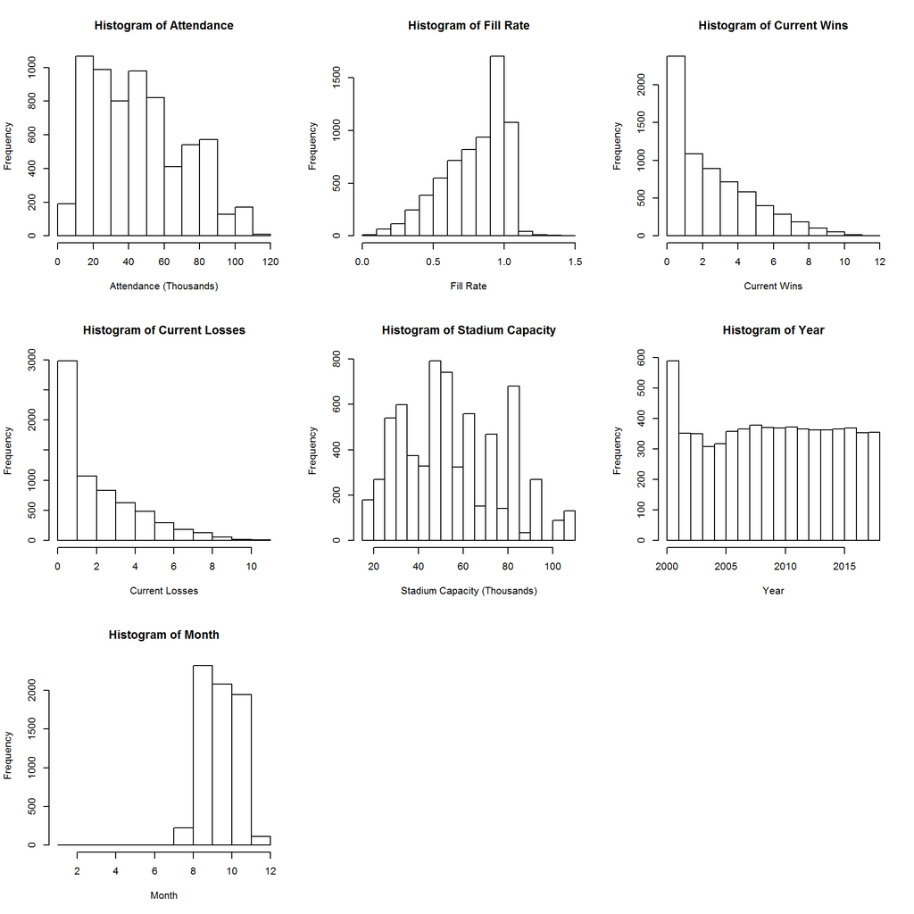

In order to understand the data provided, the variables were first analyzed in histograms. Attendance is distributed fairly evenly with most of the game attendance between 20,000 and 62,000. Fill rate sometimes exceeds 100% when some stadiums are over capacity, but there is a skew to the left. The current wins and losses both are skewed to the right, with most at 0-2. This makes sense intuitively as every team has to begin the season with 0 wins and 0 losses. Stadium capactity is seemingly distributed evenly throughout, with some peaks at different points. From 2000-2018, there are even amounts of data points for the home games, making it easier to observe trends in the given time frame. Regarding the months recorded, the games are all in the fall during the main college football season. The games that were played in April were just Memphis spring games that were somehow included in the dataset. We removed those games in order to have consistent analysis of the data. Also, one game was incorrectly marked as occurring in January instead of December, so we fixed that.

In the data set, there were multiple teams that were placed into the wrong conferences at certain points in time. The data was fixed to correct this issue.

## B. Continouous Predictors

### 1. Plots

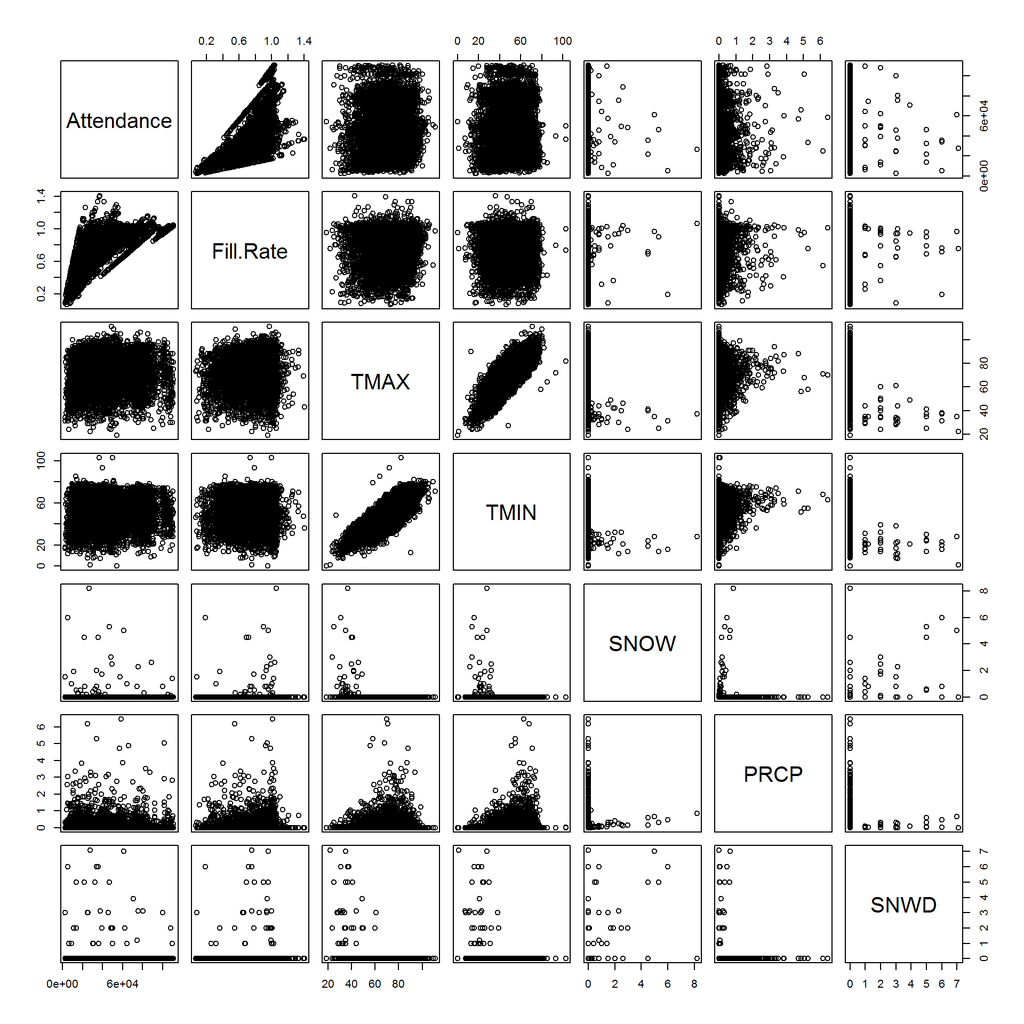

### 2. Analysis

As we would expect, fill rate and attendance are very positively correlated as they are both measurements of attendance. It does not seem that temperature (either max or min) has much of a relationship with attendance or fill rate. If there is a relationship, it might be with an interaction with one or more other variables. There are not many observations of snowfall or snow depth of an inch or more, but there does appear to be a negative correlation between both measures and attendance. Negative correlations with fill rate are not as apparent from the plot, indicating that some of the correlation with attendance could be because stadiums where heavy snowfall occurred have lower than average capacities. Precipitation also looks like it has a slight negative correlation with attendance, with a correlation with fill rate less clear.

Maximum and minimum temperature obviously have a very strong positive correlation with each other. Both are also related to snowfall and snow depth as it can only snow at colder temperatures. There is also a somewhat positive relationship between temperature and precipitation.

## C. Discrete Predictors

### 1. Attendance Plots

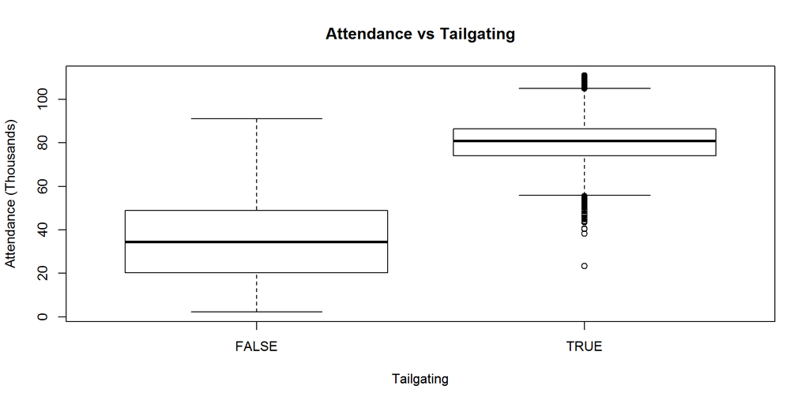

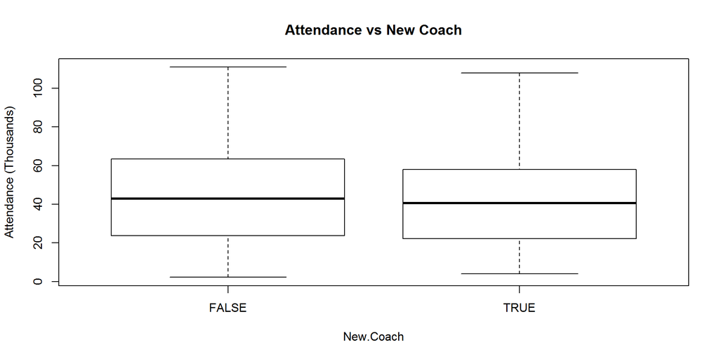

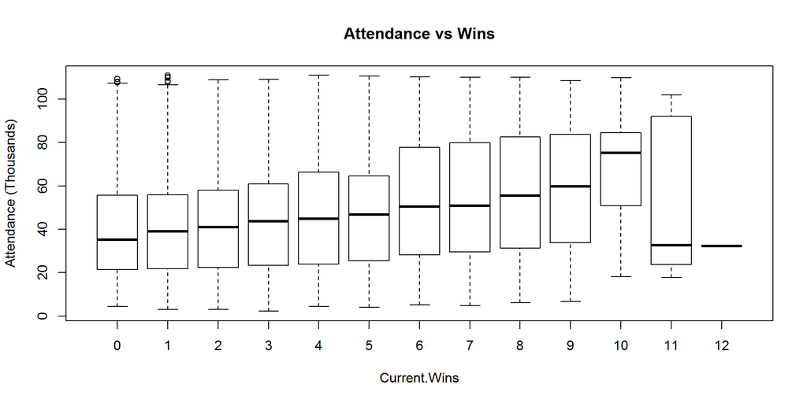

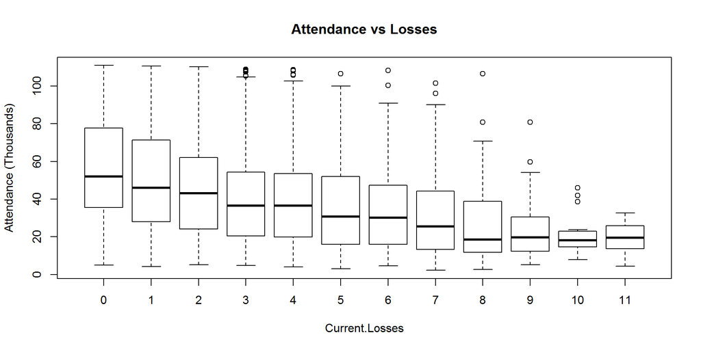

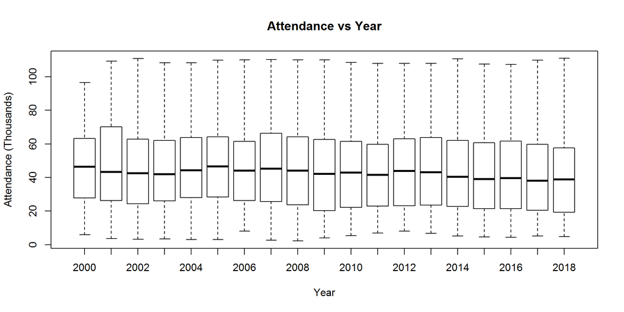

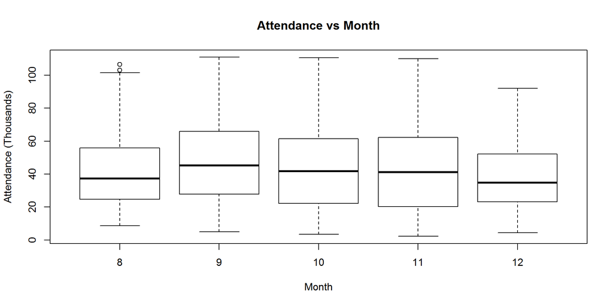

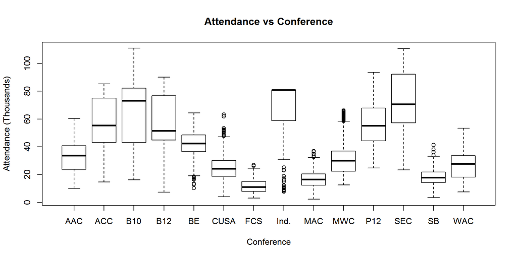

### 2. Fill Rate Plots

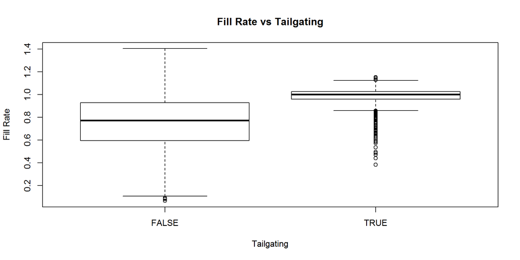

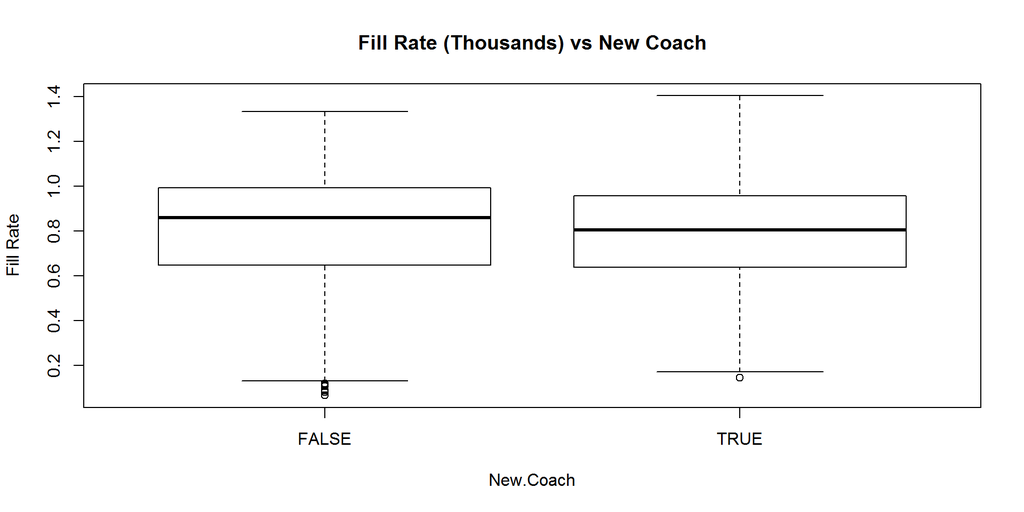

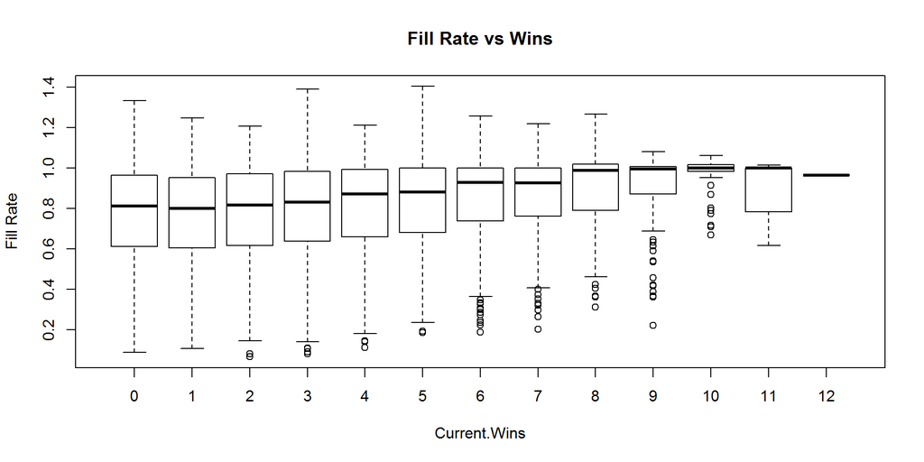

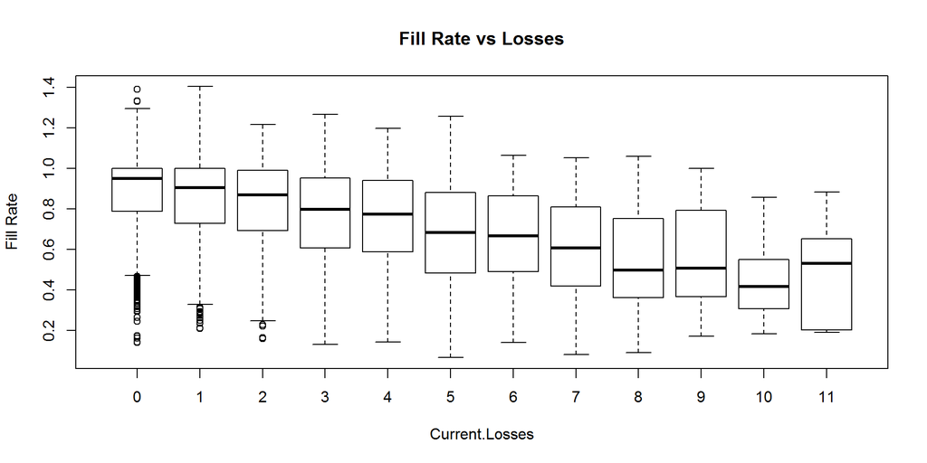

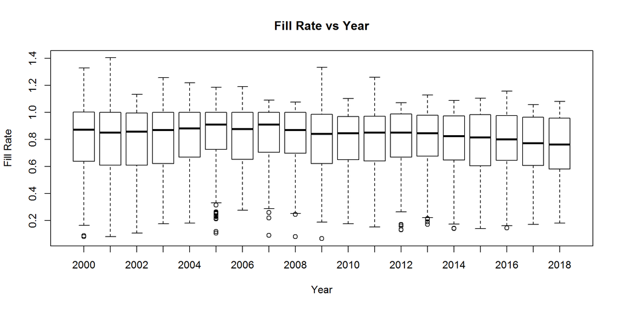

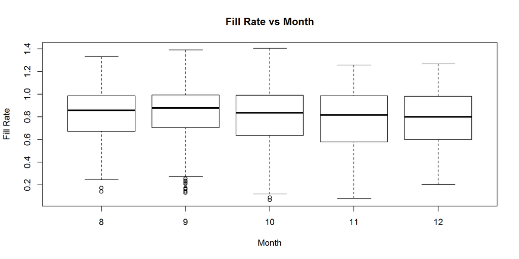

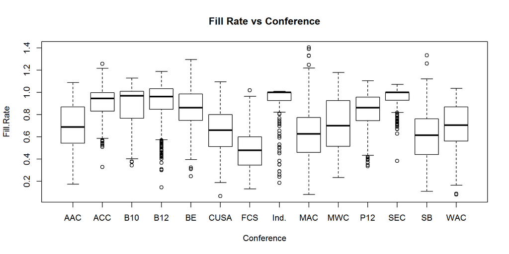

### 3. Analysis

The boxplots for the discrete variables show similar trends for both attendance and fill rate. The differences that exist between plots for a variable against attendance and fill rate illustrate the nature of the relationships between these variables.

Generally, the schools rated as being top 25 in tailgating have higher attendance than other schools. However, some of this is because these schools have larger stadiums. We can see from the fill rate boxplot that the top tailgating schools do have a higher fill rate but that the difference is not as large as the attendance chart made it look.

The differences in attendance and fill rate for schools with a new coach are small but noticeable. Schools with a new coach, on average, have lower attendance than schools with a returning coach.

As to be expected, attendance and fill rate inscrease with more wins and decrease with more losses. Weird outliers like attendance decreasing with 11 and 12 wins are due to instances of Boise State playing home games with 11 and 12 wins. Boise State has a fairly small stadium capacity.

Attendance and fill rate have both decreased over the years in the sample, with both on a mostly steady decline since 2005-2007.

Both measures decrease by month from September through November. It is harder to draw conclusions about August or December as there are only 220 observations in August and 111 observations in December out of the 6662 total observations in our sample dataset.

We can observe a sort of heirarchy in conference attendance and fill rate, with the SEC having the highest fill rates of any conference. Independents have good attendance and fill rate largely due to Notre Dame, one of the most popular college football teams, being one of a small number of independent schools. Not surprisingly, schools in the lower FCS classification (or something similar like Division I-AA), had very low attendance and fill rates.